# FINANCIAL CONTRIBUTION TO PRESIDENTIAL CAMPAIGN BY STATE by Venkatesh Prasad

This report is an exploration of the Financial contributions to presidential campaign by the state Alaska

```
## [1] 22136    18
```

```
## 'data.frame':    22136 obs. of  18 variables:
##  $ cmte_id          : chr  "C00577130" "C00577130" "C00575795" "C00577130" ...
##  $ cand_id          : Factor w/ 19 levels "P00003392","P20002671",..: 11 11 1 11 1 13 13 13 11 11 ...
##  $ cand_nm          : Factor w/ 19 levels "Bush, Jeb","Carson, Benjamin S.",..: 15 15 4 15 4 12 12 12 15 15 ...
##  $ contbr_nm        : Factor w/ 4381 levels "'CALLICOTT, MIKE",..: 2486 2487 3398 2488 1609 3085 3085 3085 3078 3078 ...
##  $ contbr_city      : Factor w/ 178 levels "","4268 SOUTH EIDER C",..: 97 34 55 12 63 12 12 12 131 131 ...
##  $ contbr_st        : Factor w/ 1 level "AK": 1 1 1 1 1 1 1 1 1 1 ...
##  $ contbr_zip       : int  996100702 995675247 995773626 995043034 997080167 995015765 995015765 995015765 998331284 998331284 ...
##  $ contbr_employer  : Factor w/ 1503 levels "","907 DESIGNS",..: 1174 555 1130 963 1395 940 940 940 1042 1042 ...
##  $ contbr_occupation: Factor w/ 1312 levels "","10TH PLANET",..: 906 1099 1187 786 1049 1041 1041 1041 972 972 ...
##  $ contb_receipt_amt: num  35 25 100 27 100 ...
##  $ contb_receipt_dt : Factor w/ 613 levels "01-APR-15","01-APR-16",..: 91 71 238 91 217 325 385 569 91 110 ...
##  $ receipt_desc     : Factor w/ 10 levels "","* EARMARKED CONTRIBUTION: SEE BELOW REATTRIBUTION/REFUND PENDING",..: 1 1 1 1 1 1 1 1 1 1 ...
##  $ memo_cd          : Factor w/ 2 levels "","X": 1 1 2 1 2 1 1 1 1 1 ...
##  $ memo_text        : Factor w/ 28 levels "","* EARMARKED CONTRIBUTION: SEE BELOW",..: 2 2 4 2 4 1 1 1 2 2 ...
##  $ form_tp          : Factor w/ 3 levels "SA17A","SA18",..: 1 1 2 1 2 1 1 1 1 1 ...
##  $ file_num         : int  1077404 1077404 1091718 1077404 1091718 1144666 1144666 1144666 1077404 1077404 ...
##  $ tran_id          : Factor w/ 22119 levels "A013197394B604632A56",..: 16345 16307 4944 16367 4814 22117 22118 22119 16342 16404 ...
##  $ election_tp      : Factor w/ 4 levels "","G2016","O2016",..: 4 4 4 4 4 4 4 4 4 4 ...
```

```
##    cmte_id               cand_id                          cand_nm
##  Length:22136       P60007168:8773   Sanders, Bernard         :8773
##  Class :character   P00003392:7078   Clinton, Hillary Rodham  :7078
##  Mode  :character   P80001571:2170   Trump, Donald J.         :2170
##                     P60006111:2130   Cruz, Rafael Edward 'Ted':2130
##                     P60005915:1275   Carson, Benjamin S.      :1275
##                     P60006723: 214   Rubio, Marco             : 214
##                     (Other)  : 496   (Other)                  : 496
##              contbr_nm          contbr_city   contbr_st
##  DIRCEU, JOSE     :  317   ANCHORAGE  :7805   AK:22136
##  JONES, D CALDWELL:  272   FAIRBANKS  :2437
##  ALMEIDA, PEDRO   :  146   JUNEAU     :2212
##  ANDERSON, EDWARD :   91   WASILLA    :1007
##  GORDON, ROD      :   88   PALMER     : 912
##  KLEINER, T. K.   :   87   EAGLE RIVER: 774
##  (Other)          :21135   (Other)    :6989
##    contbr_zip             contbr_employer              contbr_occupation
##  Min.   :      600   RETIRED      : 2818   RETIRED              : 4642
##  1st Qu.:995042050   N/A          : 2260   NOT EMPLOYED         : 2693
##  Median :995779721   NONE         : 1683   INFORMATION REQUESTED:  824
##  Mean   :840857173   NOT EMPLOYED : 1374   PHYSICIAN            :  411
##  3rd Qu.:997093447   SELF-EMPLOYED: 1321   TEACHER              :  407
##  Max.   :999292211   (Other)      :12678   ATTORNEY             :  347
##  NA's   :9           NA's         :    2   (Other)              :12812
##  contb_receipt_amt   contb_receipt_dt
##  Min.   :-3200.00   31-MAR-16:  259
##  1st Qu.:   15.40   29-FEB-16:  252
##  Median :   35.00   30-APR-16:  201
##  Mean   :   79.15   14-MAR-16:  194
##  3rd Qu.:  100.00   31-MAY-16:  188
##  Max.   : 5400.00   30-MAR-16:  176
##                     (Other)  :20866
##                                                            receipt_desc
##                                                                  :21907
##  Refund                                                          :  185
##  * EARMARKED CONTRIBUTION: SEE BELOW REATTRIBUTION/REFUND PENDING:   13
##  REDESIGNATION FROM PRIMARY                                      :   12
##  REDESIGNATION TO GENERAL                                        :   12
##  REATTRIBUTION FROM SPOUSE                                       :    2
##  (Other)                                                         :    5
```

[output cut: 9 more lines]

```
##                                                                  :12238
##  * EARMARKED CONTRIBUTION: SEE BELOW                             : 8519
##  * HILLARY VICTORY FUND                                          : 1276
##  EARMARKED FROM MAKE DC LISTEN                                   :   22
##  * EARMARKED CONTRIBUTION: SEE BELOW REATTRIBUTION/REFUND PENDING:   13
##  *BEST EFFORTS UPDATE                                            :   12
##  (Other)                                                         :   56
##   form_tp         file_num            tran_id      election_tp
##  SA17A:19220   Min.   :1003942   C10224499:    2        :   35
##  SA18 : 2731   1st Qu.:1077572   C10245593:    2   G2016: 5969
##  SB28A:  185   Median :1091718   C10284315:    2   O2016:    4
##                Mean   :1096208   C10296519:    2   P2016:16128
##                3rd Qu.:1126927   C1059809 :    2
##                Max.   :1146285   C13812768:    2
##                                  (Other)  :22124
```

This dataset contains 22,136 observations and 18 variables. The summary of the dataset is depicted above.

# Univariate plot section

```
## [1] 3
```

There are 3 contributions above 2700$. They have been removed from the dataset since it is against the Federal Election Campaign Act.

```
## [1] 271
```

```
## [1] ""      "G2016" "O2016" "P2016"
```

```
## [1] 34
```

There are 34 contributions which does not belong to any of the election type. So they are removed from the dataset.

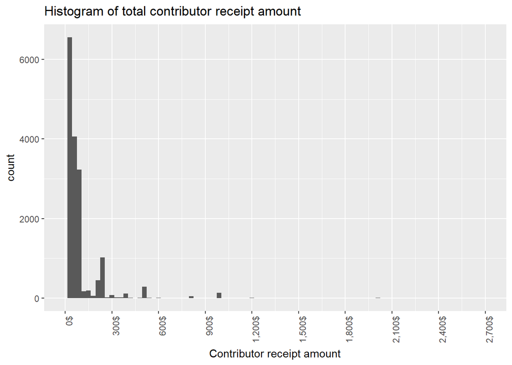

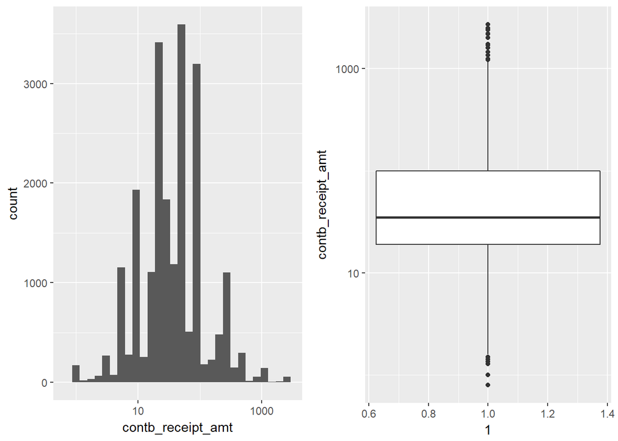

In the above plots, the x scale is transformed for better visulaization since the first one has long tail(right skewed) and difficult to infer. The histogram shows most of the contribution amount lies in the range 5$ to 900$. The box plot clearly shows the outliers in the contribution receipt amount.

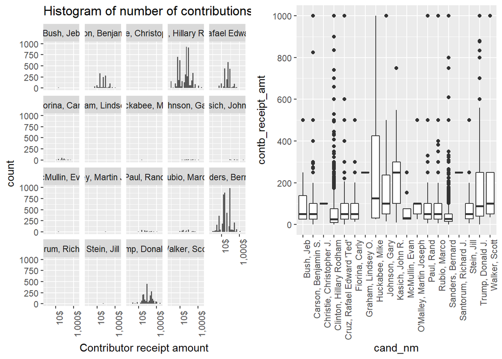

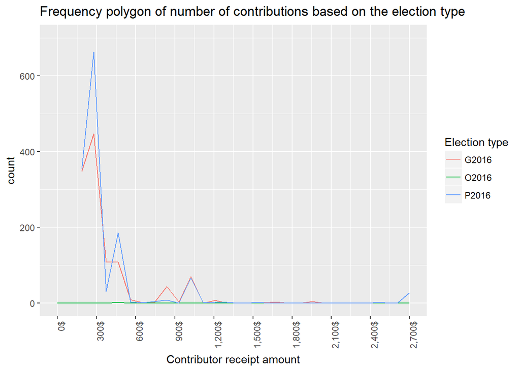

The above grapgh shows the frequency polygon of Contributor receipt amount based on the Election type. Here ‘G2016’ represents 2016 General election, ‘O2016’ represent 2016 Other election and ‘P2016’ represents 2016 Primary election.

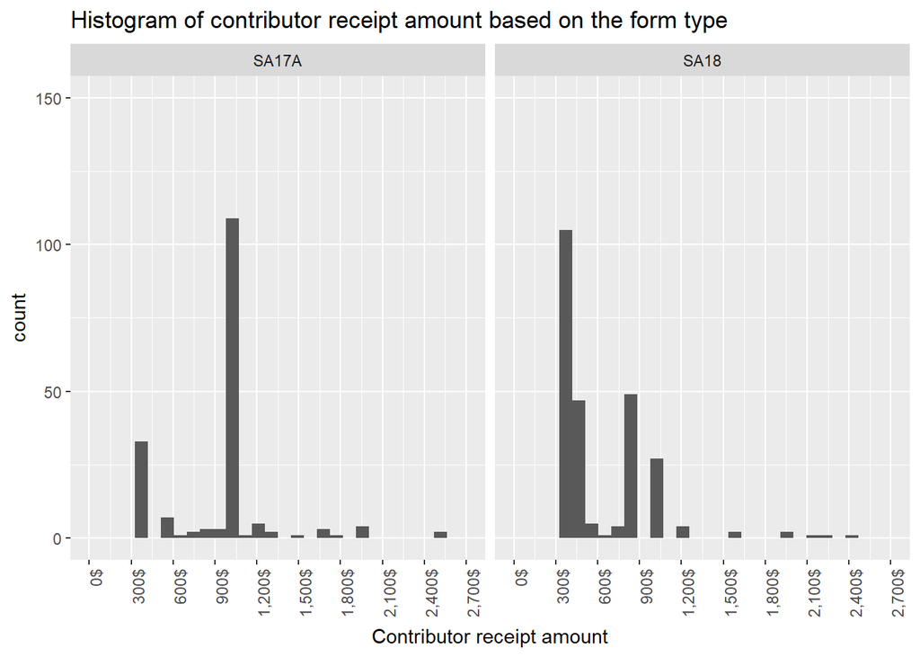

The above plot represents the histogram of Contributor receipt amount based on the Form type. Here, ‘SA17A’ i.e Form 3P Schedule A Line 17A represents Individiual contributions and ‘SA18’ i.e Form 3P Schedule A Line 18 represents transfers from authorized committees. It can be observed that transfers from authorized committees are slightly larger than the individiual contributions.

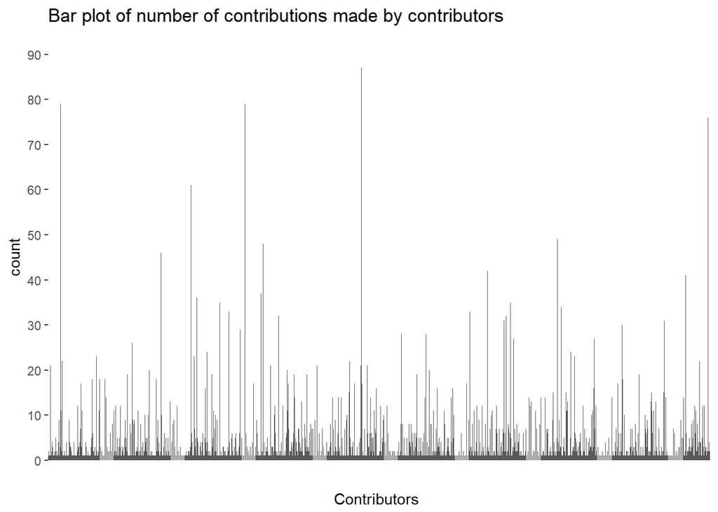

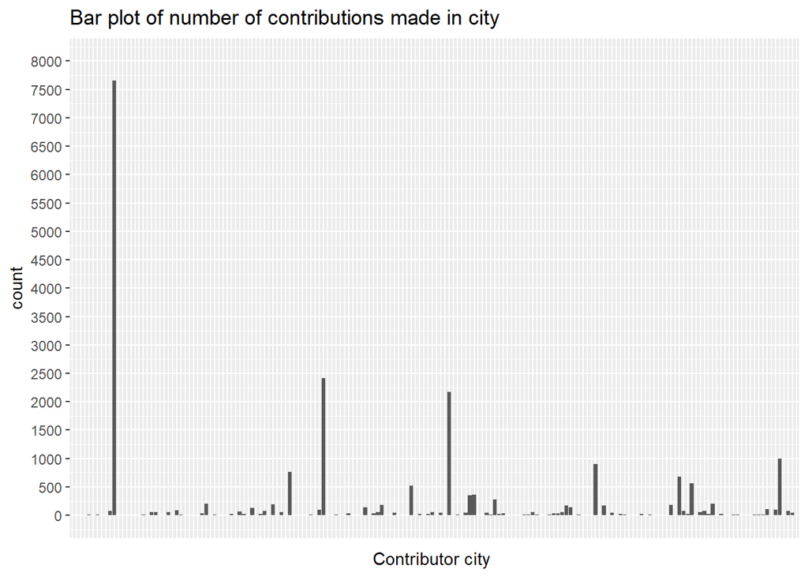

In the above plot, it can be observed that the maximum contribution made by a city reached between 7500 and 8000 in count.

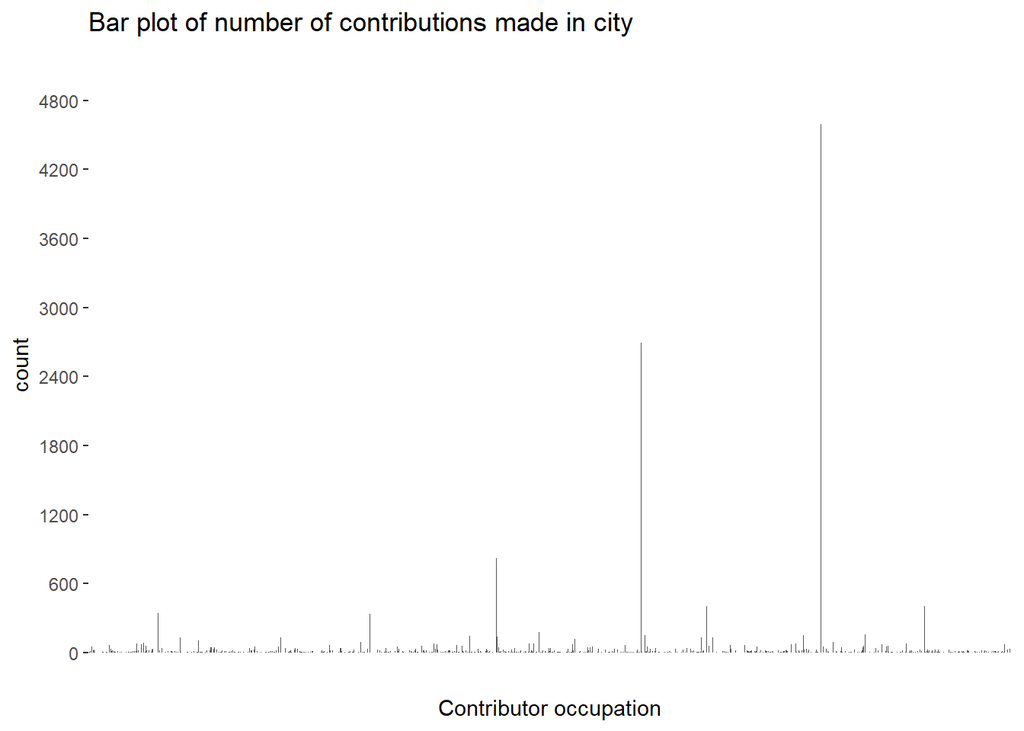

Here, we can observe that the contribution made by a particular occupation reaches a maximum count between 4500 and 5000.

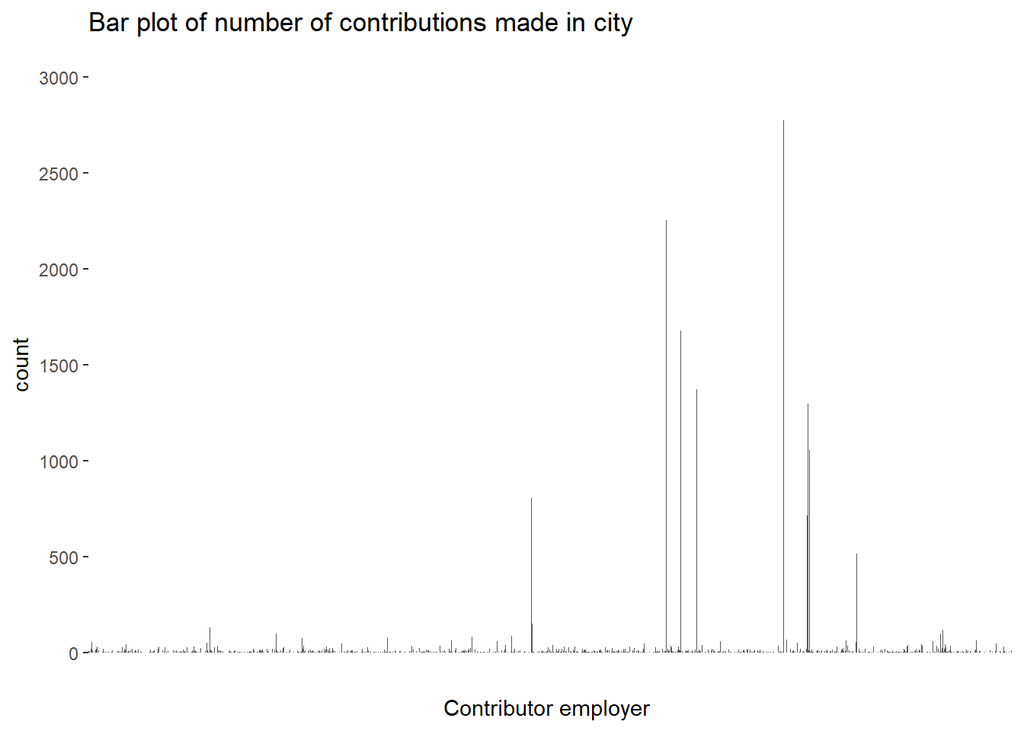

In this plot, the maximum number of contribution by a particular employer reaches a maximum count of around 2750.

# Univariate Analysis

### What is the structure of your dataset?

There are 22,136 observations and 18 features. Among the 18 features Contributor receipt amount, contributor zip and File number are integer numbers, committee id is char string and the remaining features i.e., candidate id, candidate name, contributor name, contributor city, contributor state, contributor employer, contributor occupation, contributor receipt date, receipt description, memo code, memo text, form type, transaction id, election type are factors with various levels.

### What is/are the main feature(s) of interest in your dataset?

The main fetures of the dataset are Contributor receipt amount and Candidate name.

### What other features in the dataset do you think will help support your investigation into your feature(s) of interest?

Some of the other features such as contributor city, Contributor receipt date, Form type and Election type will support the most for the investigation.

### Did you create any new variables from existing variables in the dataset?

I added a variable Date to the dataset where I have converted the Contributor receipt date to date format.

### Of the features you investigated, were there any unusual distributions? Did you perform any operations on the data to tidy, adjust, or change the form of the data? If so, why did you do this?

I have slightly altered the data set to make it tidy. The tuples which have contribution amount which are negative and greater than 2,700$ have been removed since it is against the act. The tiples which does not have the election type are aslo removed. And Log transformation has been applied to the right skewed contribution receipt amount.

# Bivariate Plots Section

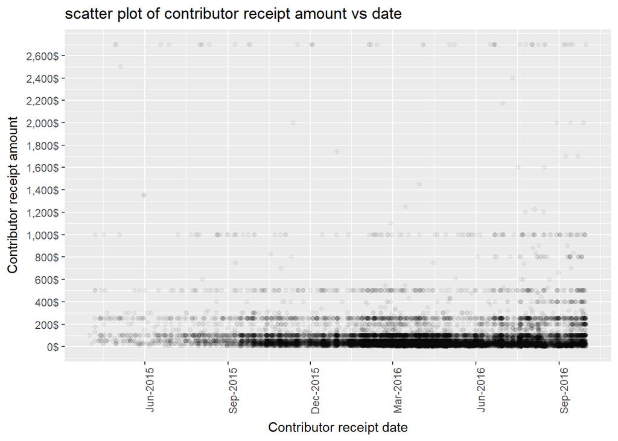

The above plot show the scatter plot of Contributor receipt amount and the contributor receipt date. But this plot is very difficult to get any insights. So the scales must be transformed for better visulaization.

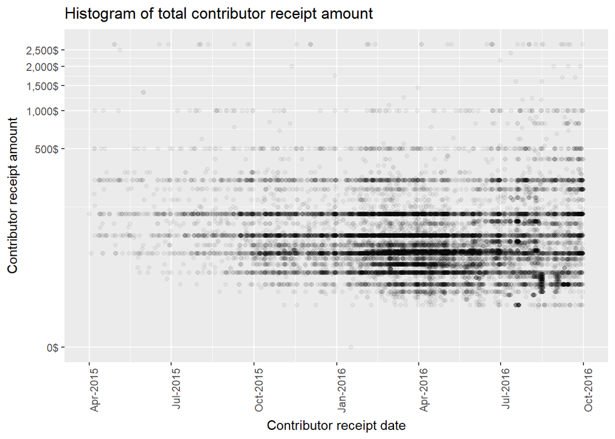

```
## # A tibble: 6 x 5
##   contbr_city contb_receipt_amt_mean contb_receipt_amt_sum
##        <fctr>                  <dbl>                 <dbl>
## 1   ANCHORAGE               99.84215             764790.85
## 2   FAIRBANKS               68.27697             164684.04
## 3      JUNEAU               67.78844             147168.70
## 4     WASILLA               86.12044              86120.44
## 5 EAGLE RIVER               86.71350              65902.26
## 6      PALMER               70.70524              63988.24
## # ... with 2 more variables: contb_receipt_amt_median <dbl>, n <int>
```

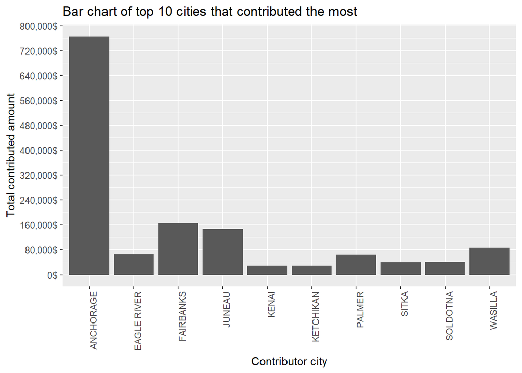

```
## # A tibble: 6 x 5
##                     cand_nm      sum      mean median     n
##                      <fctr>    <dbl>     <dbl>  <dbl> <int>
## 1   Clinton, Hillary Rodham 547904.7  78.91468  25.00  6943
## 2          Sanders, Bernard 423182.3  48.49116  27.00  8727
## 3          Trump, Donald J. 418692.7 201.77959  92.02  2075
## 4 Cruz, Rafael Edward 'Ted' 151771.7  71.82758  50.00  2113
## 5       Carson, Benjamin S. 121891.2  96.12871  50.00  1268
## 6              Rubio, Marco  31306.0 146.97653  50.00   213
```

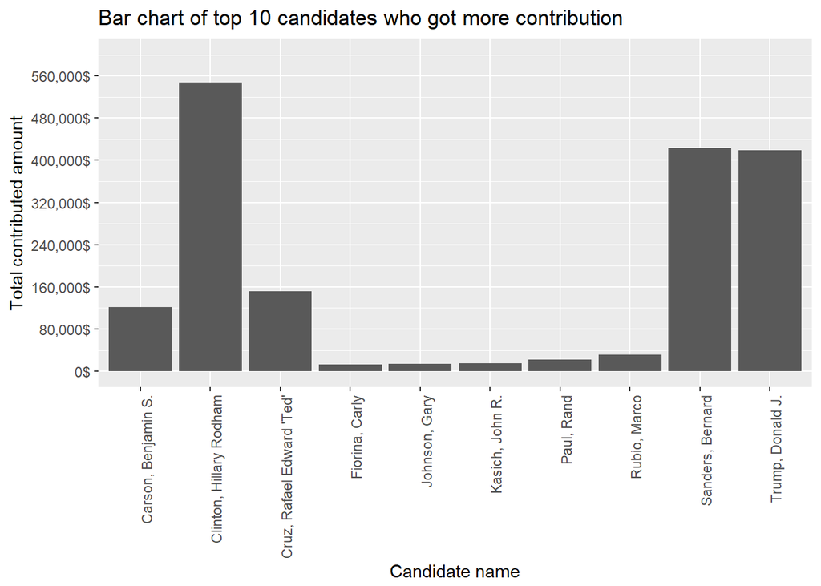

From the above bar chat it is clear that Hillary Rodham Cliton has hot the highest contrubution and Bernard Sanders and Donald J Trump has got almost equal contrinution with Bernard Sanders slightly topping Donald J Trump.

```
## # A tibble: 6 x 5
##   contbr_occupation      mean median       sum     n
##              <fctr>     <dbl>  <dbl>     <dbl> <int>
## 1           RETIRED  87.97652     50 404164.12  4594
## 2      NOT EMPLOYED  43.79280     27 117934.02  2693
## 3         PHYSICIAN 138.38771     50  56185.41   406
## 4          ATTORNEY 138.14807     35  47937.38   347
## 5          ENGINEER  86.74006     45  29144.66   336
## 6    BUSINESS OWNER 265.42740    100  27604.45   104
```

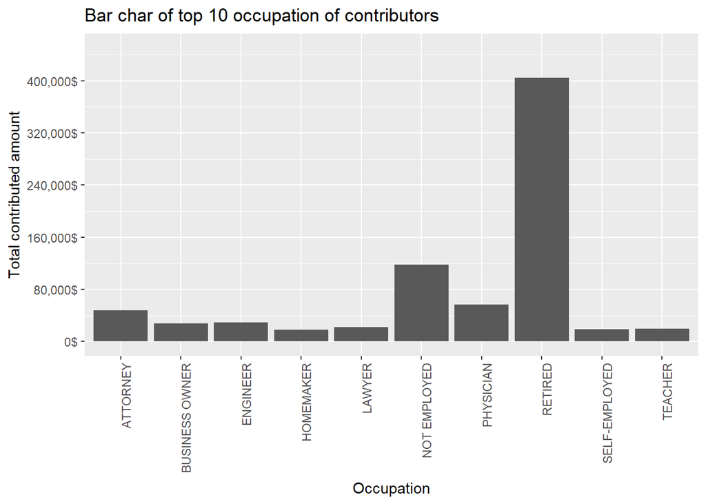

From the plot, we can say the Retired and Unemployed people has contributed most for the presidential election.

```
## [1] 19187
```

```
## [1] 2641
```

There are 19,187 contributions from the individiual person and 2,641 contributions from the authorized committee.

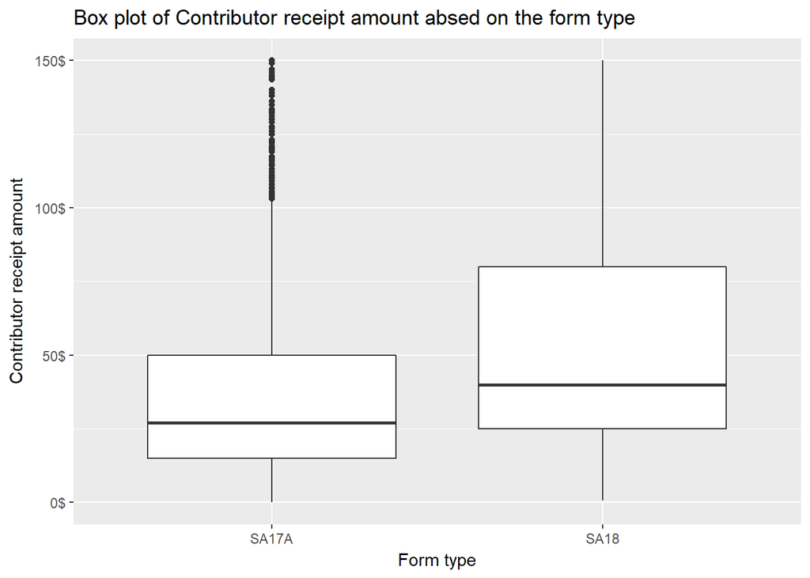

From the above box plot it is clear that contributions from authorized committe is larger than individiual contribution.

# Bivariate Analysis

### Talk about some of the relationships you observed in this part of the investigation. How did the feature(s) of interest vary with other features in the dataset?

The Contributor receipt amount varied differently with the other factor variables. The top ten observation of some factor variables have been analysed and insights are being developed.

### Did you observe any interesting relationships between the other features (not the main feature(s) of interest)?

Yes. when analyzed, the top ten observations of candidate name, contributor city, contributor occupation and cotributor employers have been found based on the contributor receipt amount.

# Multivariate Plots Section

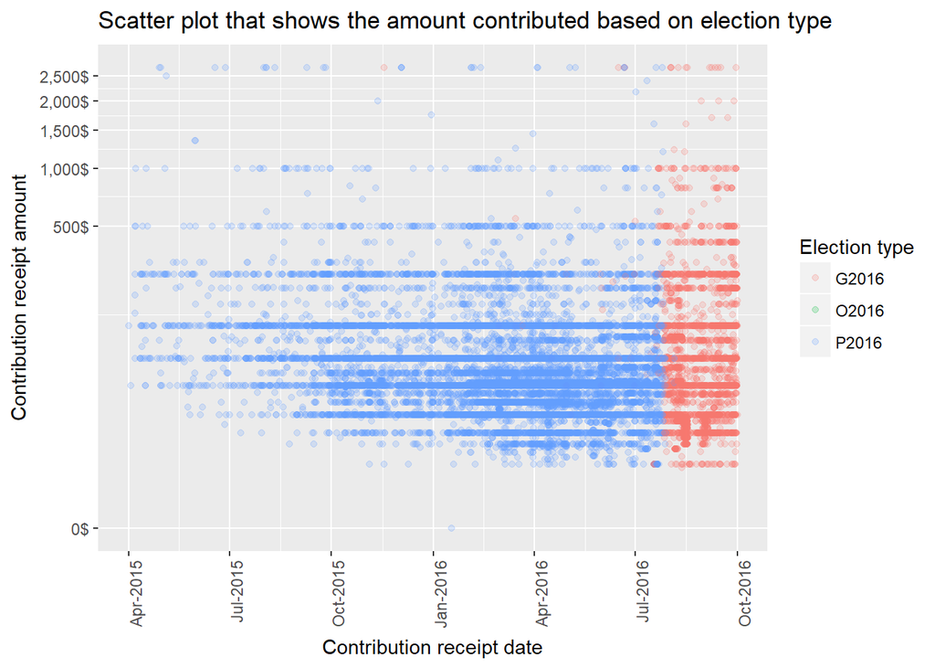

This plot clearly differentiate the amount contributed in the primary election and the general election with respect to the date. The orange color represents the general election and the blue one represents the primary election

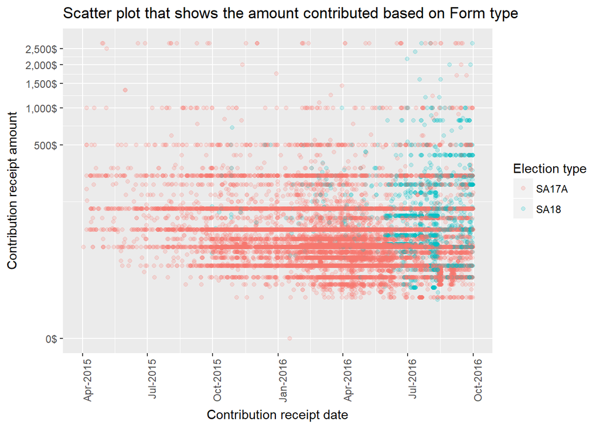

From the above plot we can infer that individiual contributions are more than transfers from authorized committee. And also, the tranfers from the authorized committee is mostly during the general election.

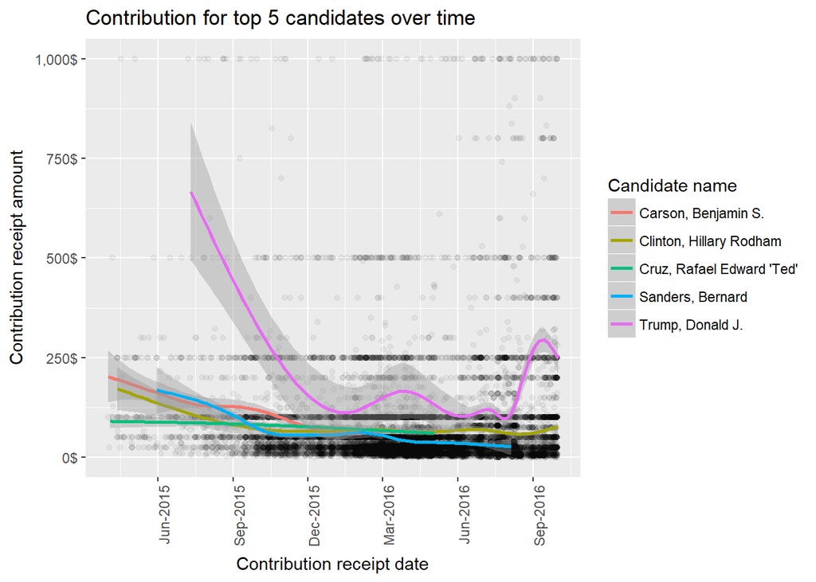

The above plot shows the scatter plot of contribution receipt amount and the contribution receipt date along with the top five contributed candidates over the time.

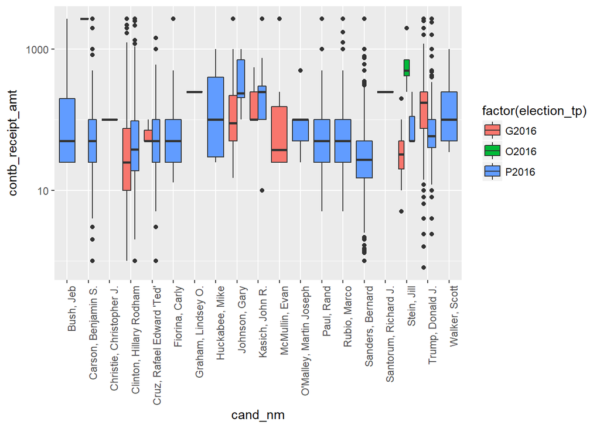

The above box plot describes contribution receipt amount for each candidate over the election type. The outliers can be easily visualized in this box plot.

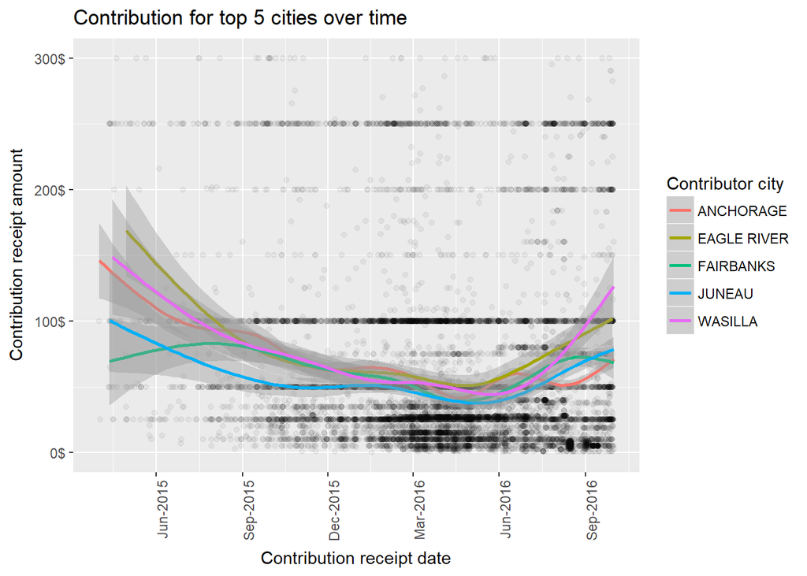

This plot shows the scatter plot of contribution receipt amount and contribution receipt date along with the top five highest contributed city over time.

# Multivariate Analysis

### Talk about some of the relationships you observed in this part of the investigation. Were there features that strengthened each other in terms of looking at your feature(s) of interest?

Many intresting relationship has been analyzed with respect to the contribution receipt date. To elaborate the features Election_tp, form_tp, cand_nm, contbr_city varied differently over time. Thus, the contribution receipt date has given a much more insight than does any other feature.

### Were there any interesting or surprising interactions between features?

One of the intresting interaction shows that Hillary Rodham Clinton who was found to be the highest contributor from the bivariate analysis has received the constant contribution over time. But the smooth curve of Donald J trump narrated a different story. That is, Donald J trump he started contributing money only from the later July 2015 but has many hikes in his contribution over time whereas Hillary Rodham Clinton started contributing money May 2015.

# Final Plots and Summary

### Plot One

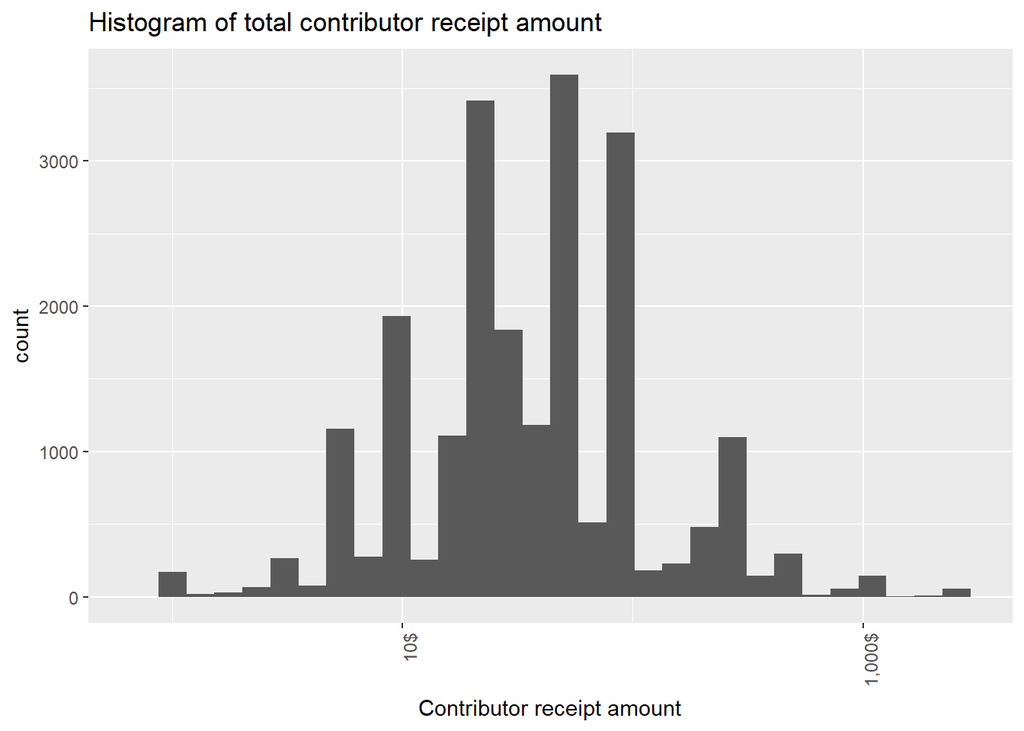

### Description One

The above histogram shows the distribution contribution receipt amount on log 10 scale. It can be observed that most of the contribution lies between 8$ and 900$

### Plot Two

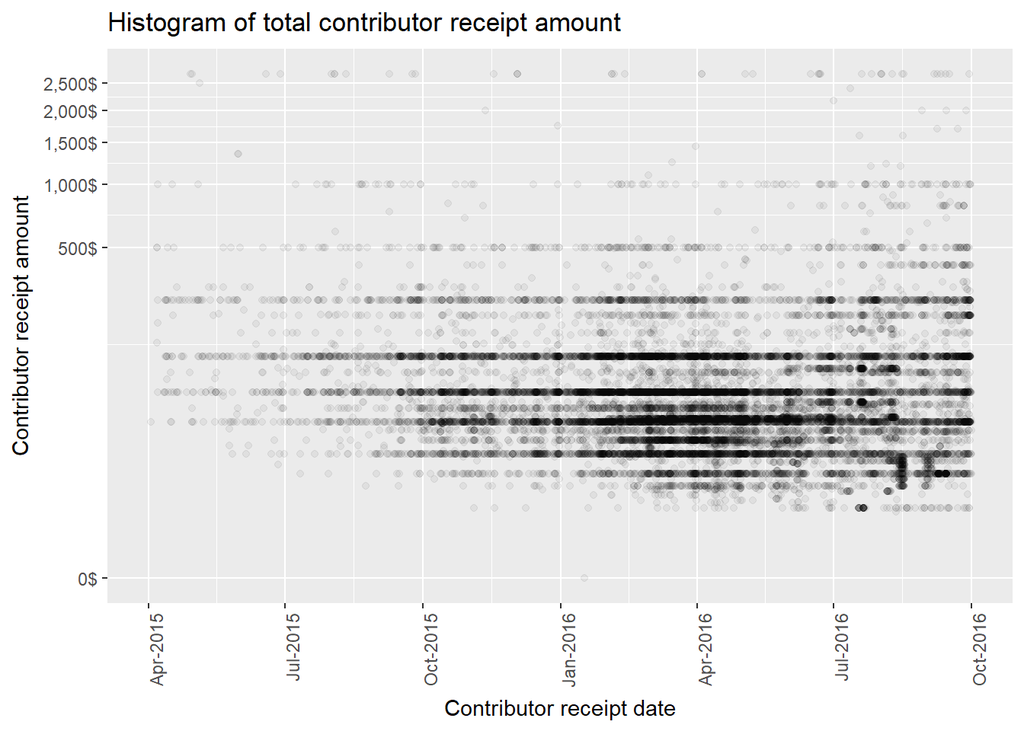

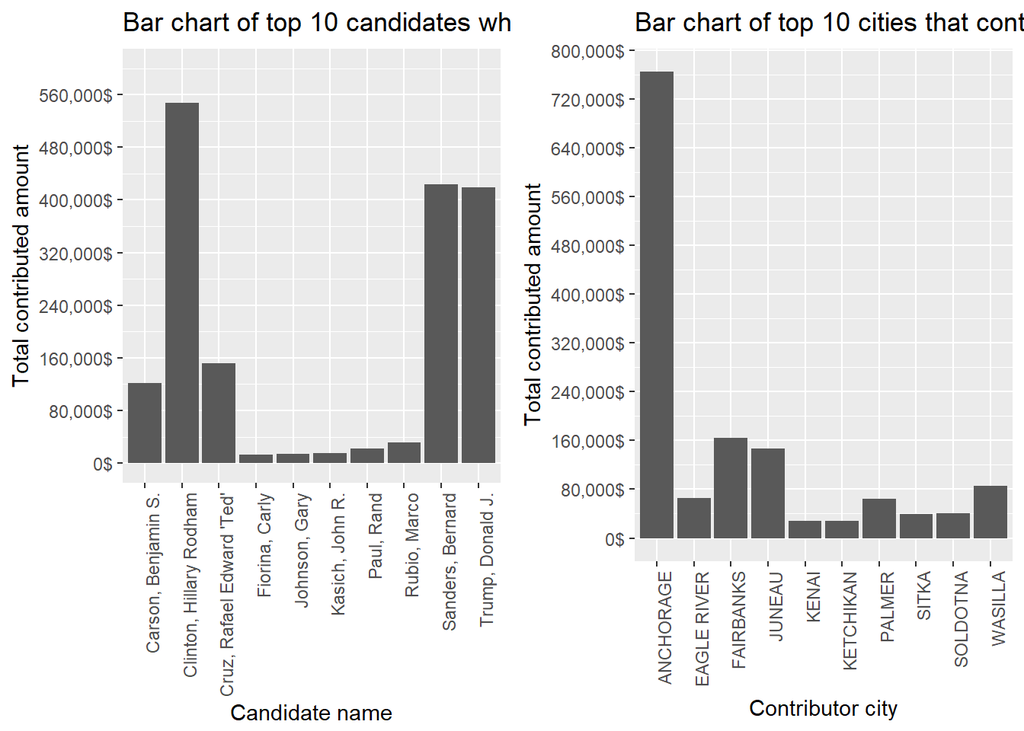

### Description Two

From these plot, it is clear that the contributions were more in the later part of the election and that can be infered from the first scatter plot. From the second bar chart we can infer that Hillary Rodham clinton has the largest contribution and Donald J Trump and Bernard Sanders has almost equal contributions. The Third bar chart shows that the highest contributing city is Anchorage. Its contribution is very high when compared to any other cities in Alaska.

### Plot Three

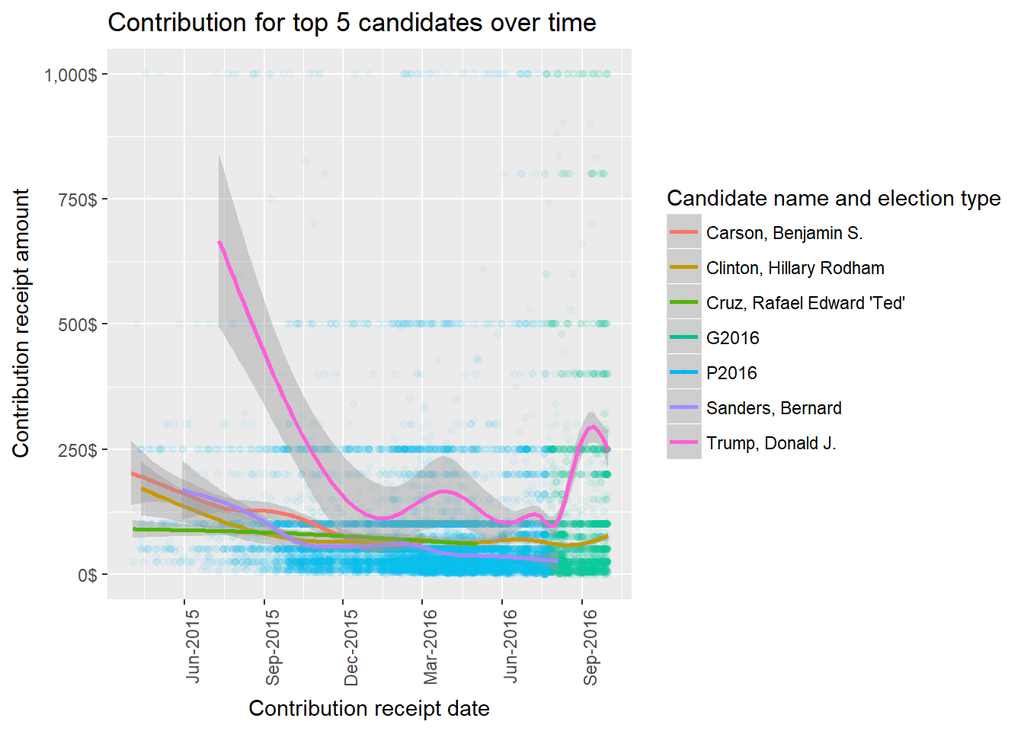

### Description Three

In this plot we can observe a very intresting pattern. In the previous plot it can be found that Hillary Rodham Clinton has contributed the highest amount. But in this plot, we can observe how Clinton’s smooth curve is constantly distributed and the variations in Trump’s curve. And also we can observe a slight hike in Trump’s curve in the general election.

# Reflection

Then I started comparing the other different features of the data set with respect to the contribution amount. It gave much more insights. Then I found the top ten observations of some features and compared those among themselves. After that, when the third variable (Contribution receipt date) comes into the play, the insights were very interesting. I explored everything with respect to the time. Thus, I can understand, though Hillary Clinton contributed the highest amount, Donald J Trump contributed more amount in a lesser period of time.

The limitations of this exploration being that, I cannot come to a conclusion that who contributed the more as a whole from this dataset because it contains onlt the details of the state Alaska. And, in the future work, I can explore further with the dataset including all the states of the United States and arrive at a conclusion.